# Weekly Energy Charts

February 17, 2023

Sign up to receive our email updates via [Substack](https://leach.substack.com/)

[interactive chart not shown]

# Featured Stories

## Update on the Keystone Spill

#### Kayla Layden

On December 7, 2022, the Keystone pipeline linking Alberta to Oklahoma and the U.S. Gulf Coast, experienced its worst spill to date, leaking diluted bitumen into Mill Creek in Washington County, Kansas. Following the spill, part of the pipeline remained shuttered for almost a month, and operating pressure has been reduced along the line since flows resumed at the end of December.

This past week, on February 9, TC Energy released updated estimates and preliminary causal findings. The spill’s size, originally estimated at 14,000 barrels, was revised down to 12,937 barrels. The company announced a welding flaw and bending stress were to blame, although the cause of this stress is still under investigation as part of a third-party review.

The large spill prompted increased discussion around the safety of pipelines and particularly of Keystone, which has experienced at least 23 spills since 2010. Although most of the incidents have been small, fewer than 50 barrels of oil, the severity seems to be growing; before December’s event, the two largest spills in Keystone’s history occurred in 2017 and 2019. The U.S. Government Accountability Office raised concerns about Keystone’s safety in 2021, especially in light of the pipeline’s special permit, which allows the line to operate at a higher stress level than is typically allowed under U.S. federal regulation. The Government Accountability Office’s report has prompted a review of the special permitting process.

Clean-up remains a significant challenge, given the impact on both the creek and nearby farmland. As part of the announcement last week, Keystone shared that investigation and remediation are expected to cost $480 million.

[Financial Post Article](https://financialpost.com/commodities/energy/oil-gas/keystone-spill-cleanup-costs-480-million)

[CBC Article](https://www.cbc.ca/news/canada/calgary/tc-energy-keystone-pipeline-leak-cause-1.6742825)

## A Second Life for EV Batteries

#### [Yousaff Habib](https://www.linkedin.com/in/yousaff-habib-6684891a5/)

A California energy start-up is leading the way in re-purposing old electric vehicle (EV) batteries into solar power storage units. The company, B2U Storage Solutions, has used “second-life” EV batteries from Honda and Nissan to reach 25 MWh of solar storage capacity at its Sierra facility in Lancaster.

The company’s proprietary plug-and-play technology utilizes the existing management systems of battery packs, virtually eliminating re-purposing costs and making the technology cost-effective. During the day, the facility’s batteries are charged by nearby solar panels and the power is sold back to the grid at night, when rates for solar power are higher. The facility generated over a million dollars in revenue last year.

According to Freeman Hall, co-founder and president of B2U, repurposed EV batteries are a good fit for solar storage as the job is less stressful than powering a car. The use of re-purposed EV batteries should result in a longer second lifespan, as the current used is much less than what the batteries are rated for, and they are not pushed to their voltage limits.

As early EV owners upgrade to newer models, the available supply of used batteries is expected to skyrocket and many could be turned into alternative energy storage solutions. This move could have far-reaching implications, with other industries, such as car manufacturers and airlines, exploring similar technology in their efforts to decarbonize their production lines and implement small-scale onsite energy storage. B2U’s Sierra facility serves as a demonstration of the potential of second-life EV batteries as solar storage units on a worthwhile scale.

You can find out more information on B2U Storage Solutions [website](https://www.b2uco.com/). This method of recycling is exactly what the renewable market as a whole should be looking at, in order to ensure that it is as sustainable as possible. The market as a whole would greatly benefit from more projects in the same vein as this.

## The IRA goes to Europe!

#### [Marc Vermette](https://www.linkedin.com/in/marc-vermette/)

At the EU’s summit last week, member states debated the Green Deal Industrial Plan; their *answer* to the US’s Inflation Reduction Act (IRA).

An analysis by a group of renewable energy companies shows that the [anticipation of the IRA](https://www.theatlantic.com/science/archive/2023/02/inflation-reduction-act-eu-green-deal-industrial-plan/672985/) alone resulted in $40 billion in new investment and the creation of over 7000 jobs in Q4 of 2022.

In Europe, on the other hand, business, industry, and startup confidence has been quickly falling.

Certain battery startups, for example, have already [migrated their operations](https://www.ft.com/content/59a8d135-3477-4d0a-8d12-20c7ef94be07) to the US, where they can more easily and affordably establish their operations.

Specific emergency measures have been recently implemented to reduce red tape for European renewable companies. For example, the EU now expedites permits for wind projects to be granted within six months. However, this only applies to new permits, and any applications submitted before this emergency measure implementation are stuck in limbo.

Many other issues like this may discourage investment in European renewables, and I hope the Green Deal Industrial Plan offers real solutions to this issue.

[Original Article](https://www.bloomberg.com/opinion/articles/2023-02-09/europe-s-green-deal-industrial-plan-has-to-cut-red-tape-on-renewables-investment)

# Oil

## Weekly Crude Prices

### Feature Crude

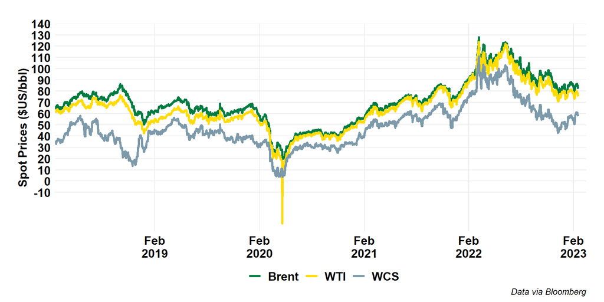

### Alberta Crude

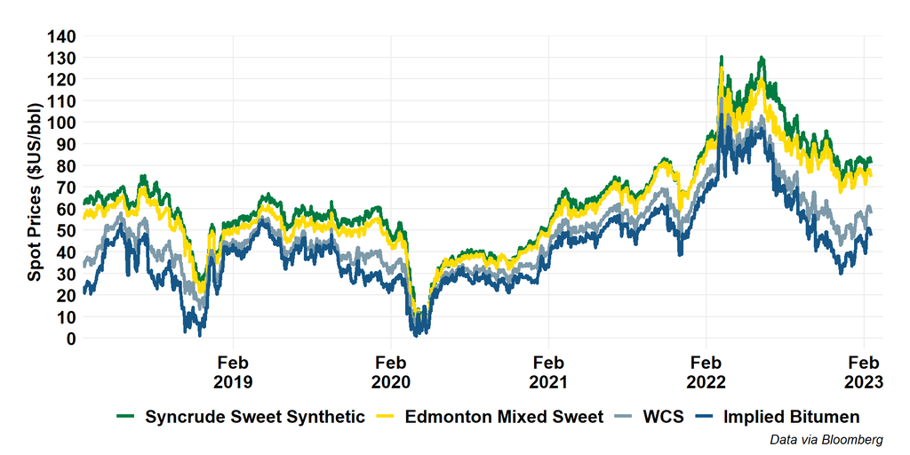

### Alberta Crude (Short)

[figure not shown]

### US Crude

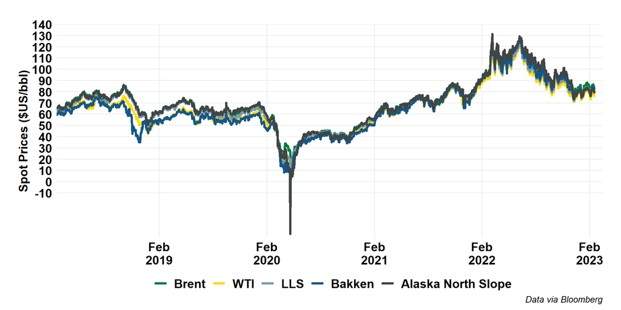

### Global Crude

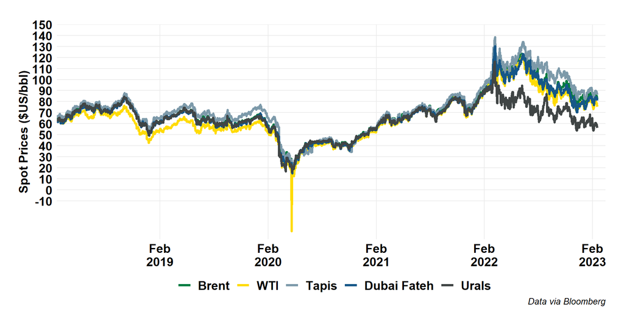

## Oil Price Differentials

### Brent-WTI

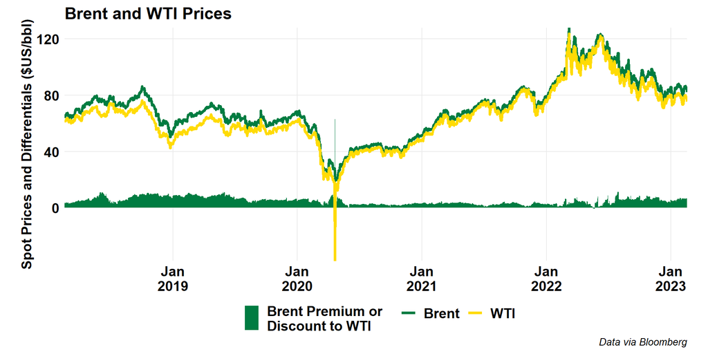

### WTI-WCS

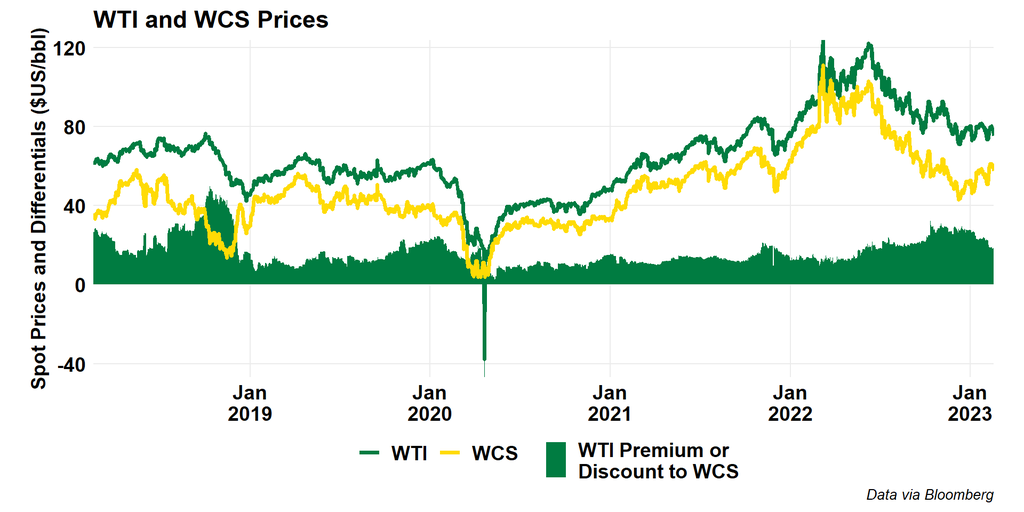

### WTI-WCS (Short)

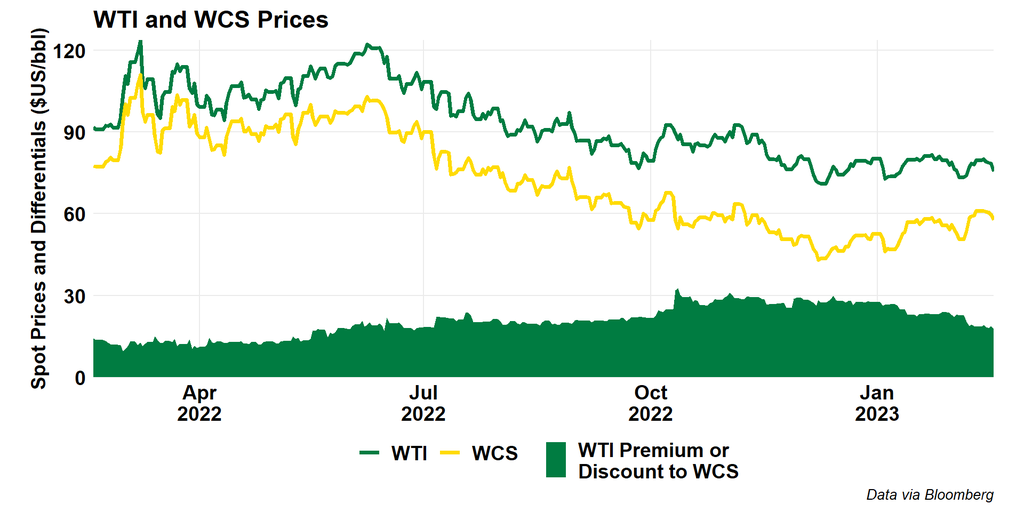

### Maya-WCS

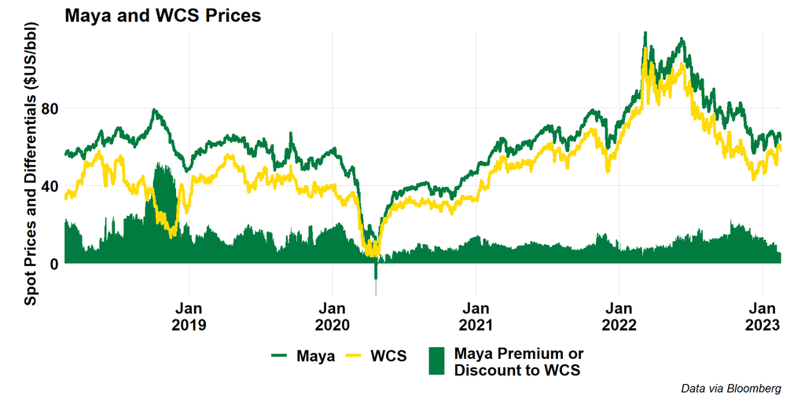

### Brent-Urals

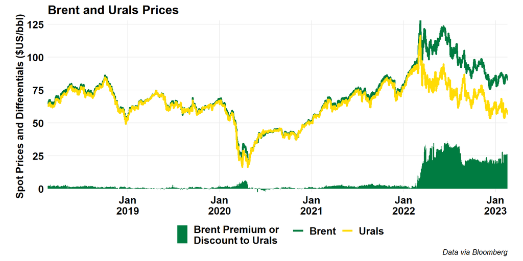

## Forward Curves

### WTI

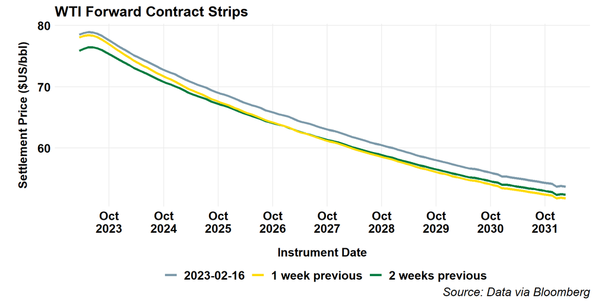

### Brent

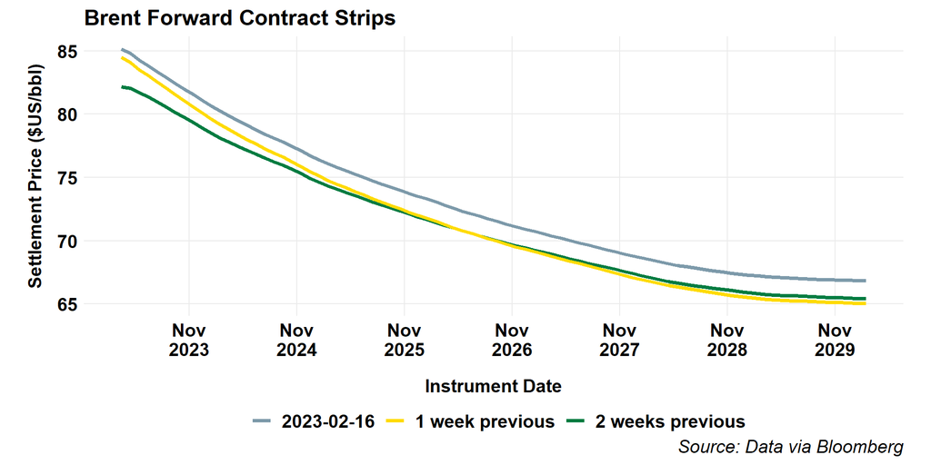

## Canadian Crude Supply and Disposition

### Canadian Production

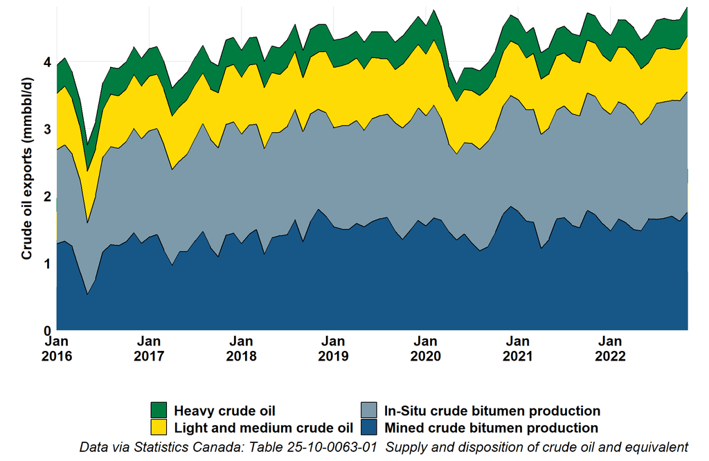

### Alberta Production

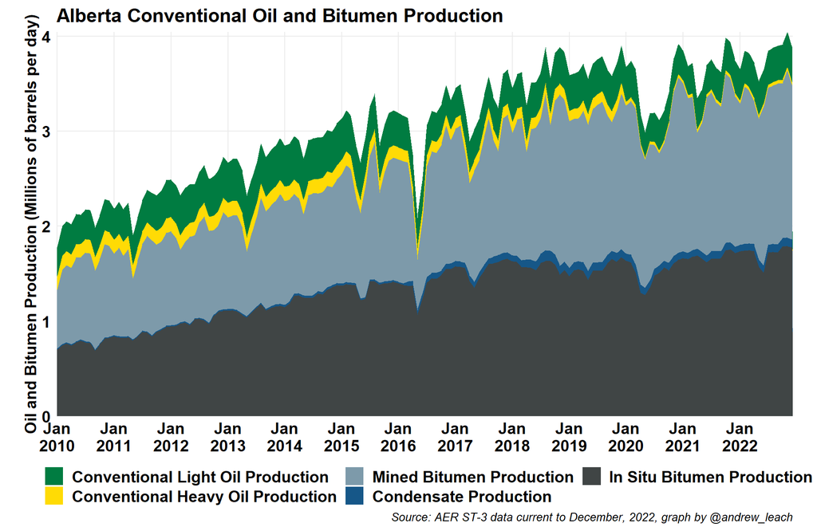

### Imports

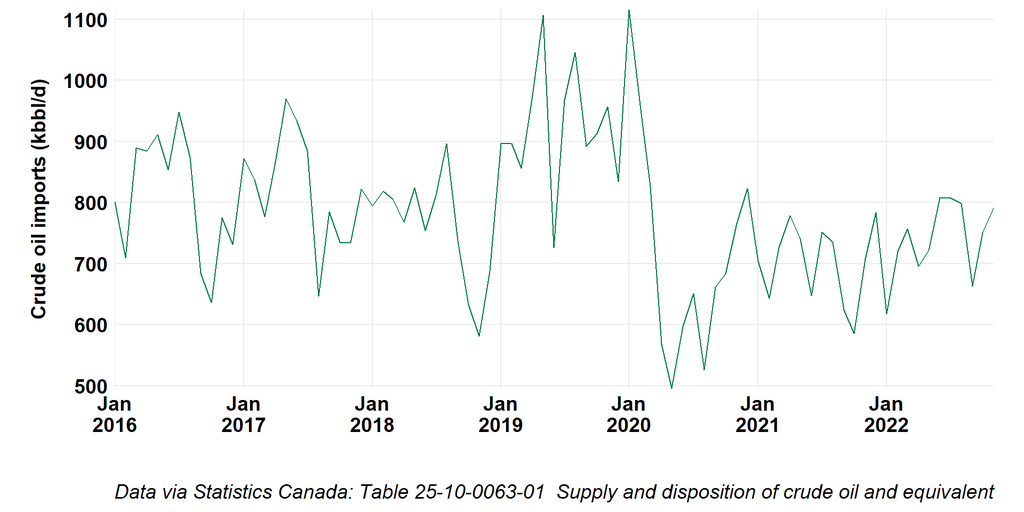

### Exports

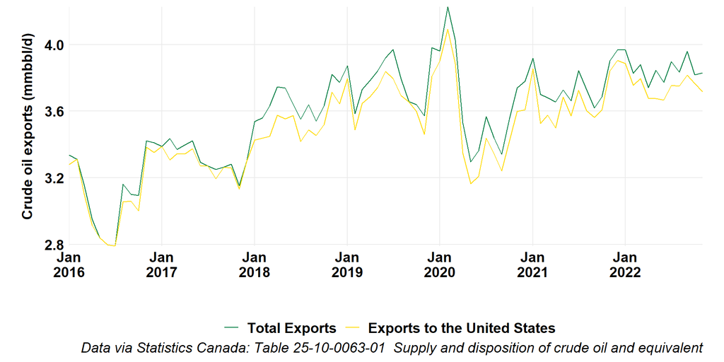

### Exports by Rail

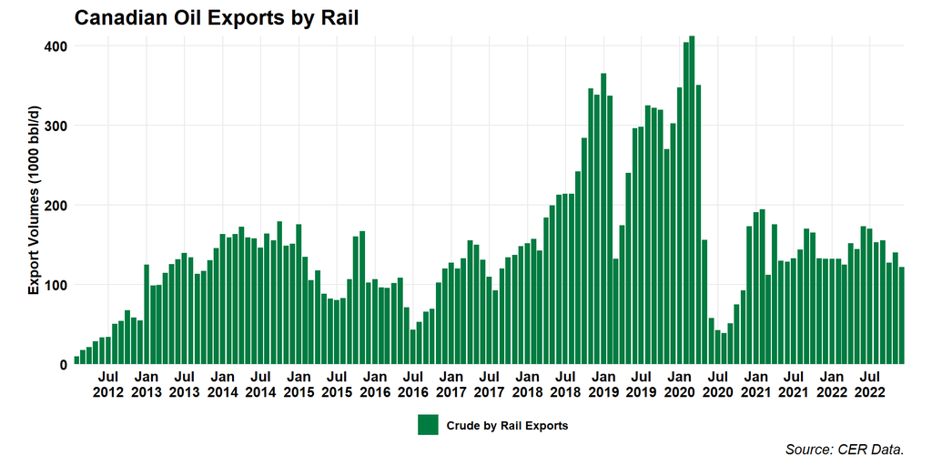

## US Oil

### Production

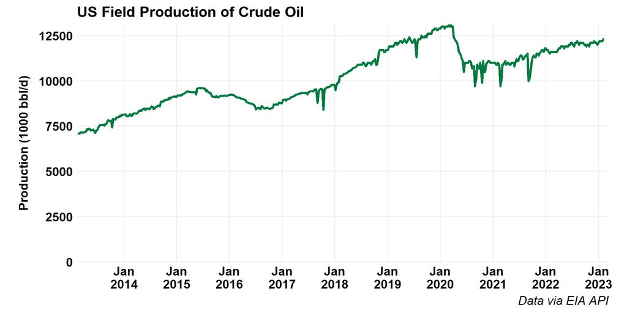

### LTO Production by Play

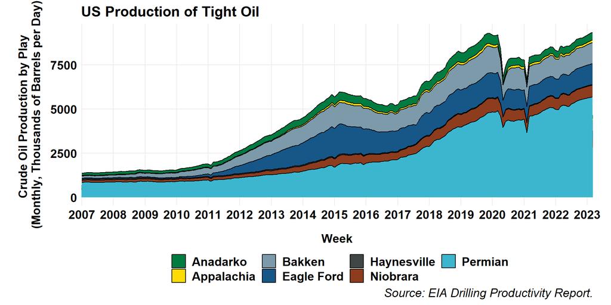

### Net Imports

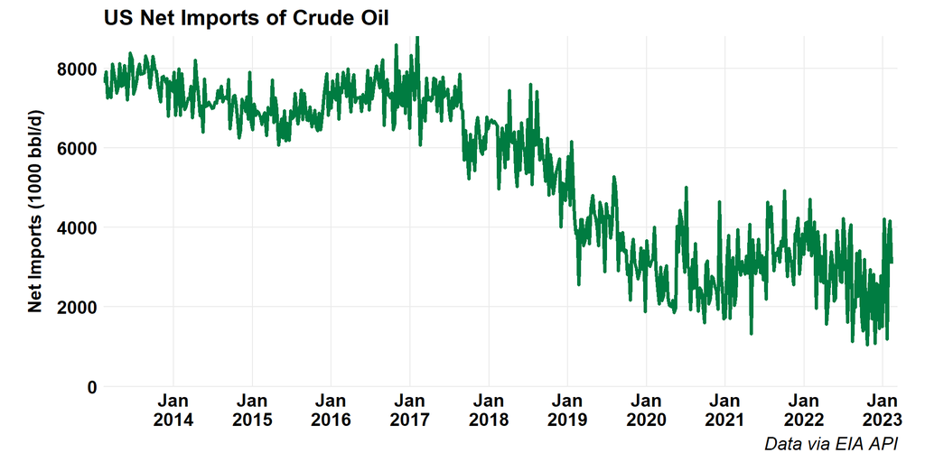

### Oil and Product Net Imports

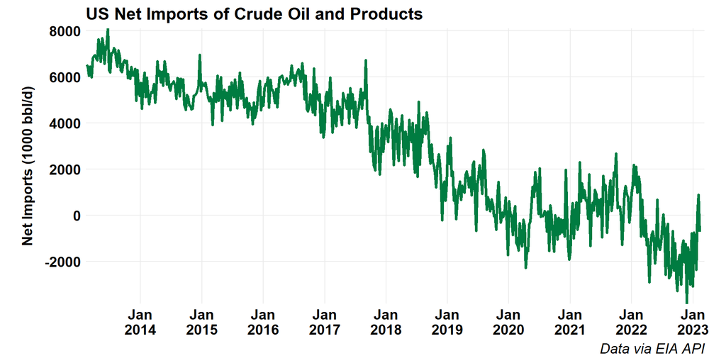

### Inventories

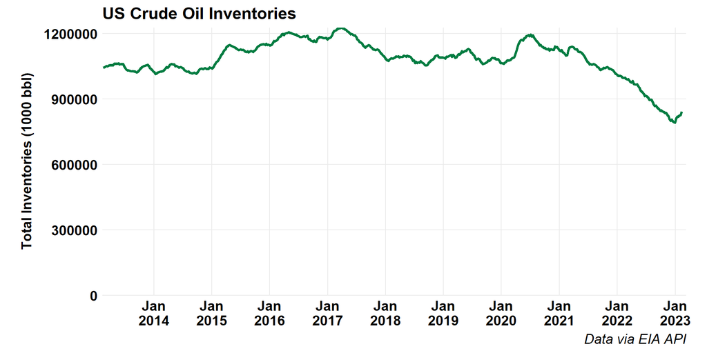

### EIA STEO Forecasts

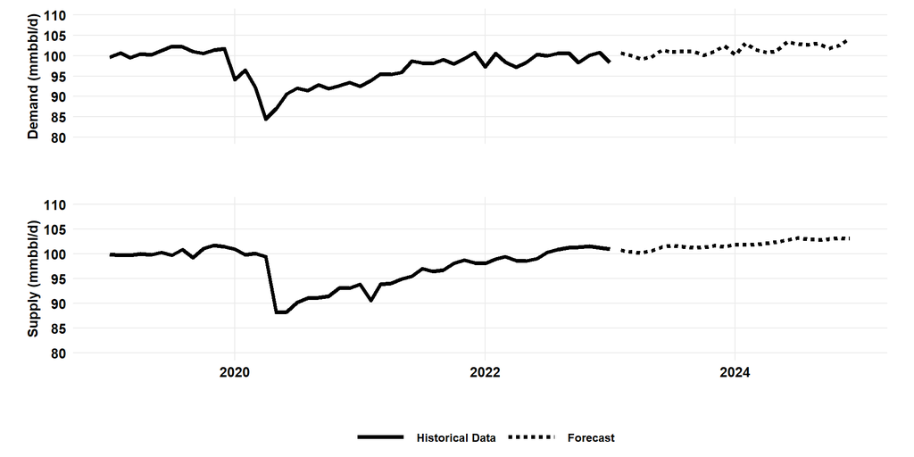

# Refined Products

## Canadian Gasoline Prices

### Map

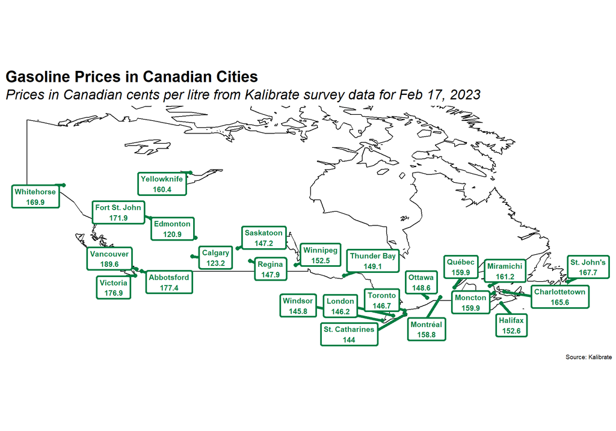

### Historic Gasoline Prices

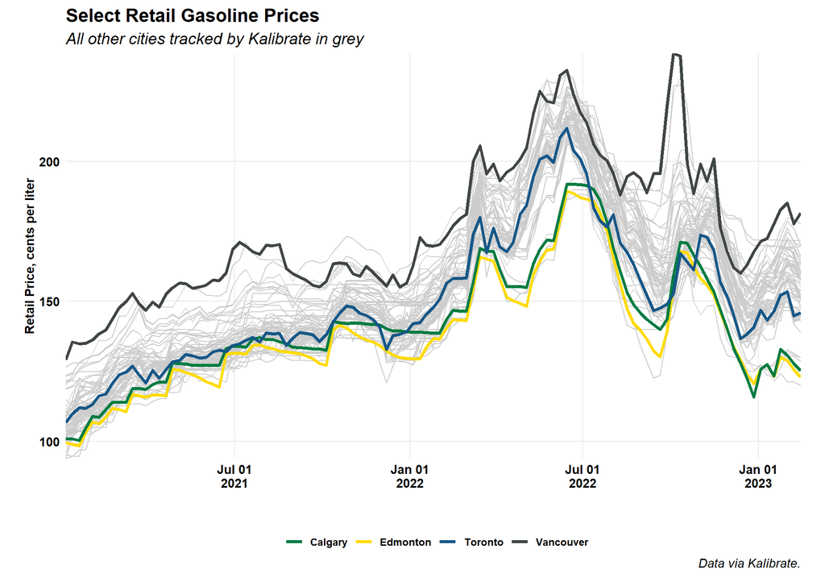

### Historic Diesel Prices

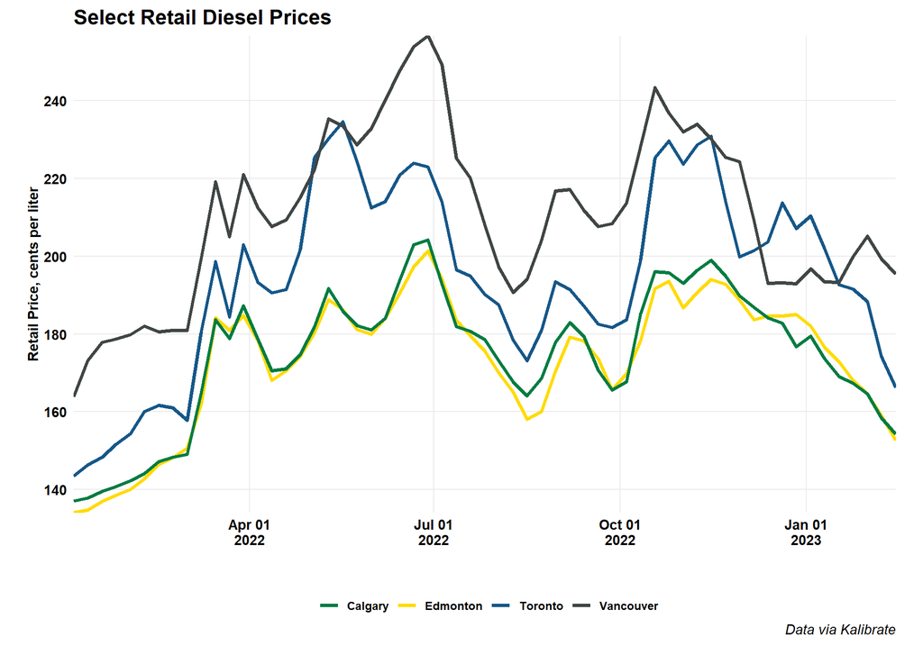

## Canadian Refinery Runs

### Canadian Refinery Runs

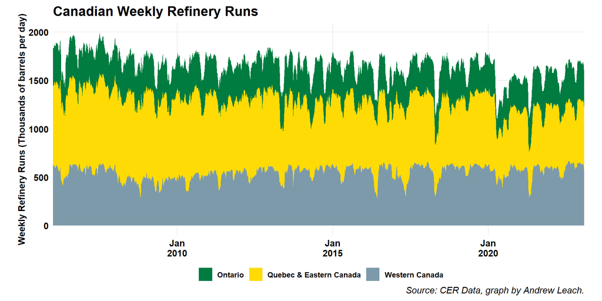

### Western Canada Refinery Runs

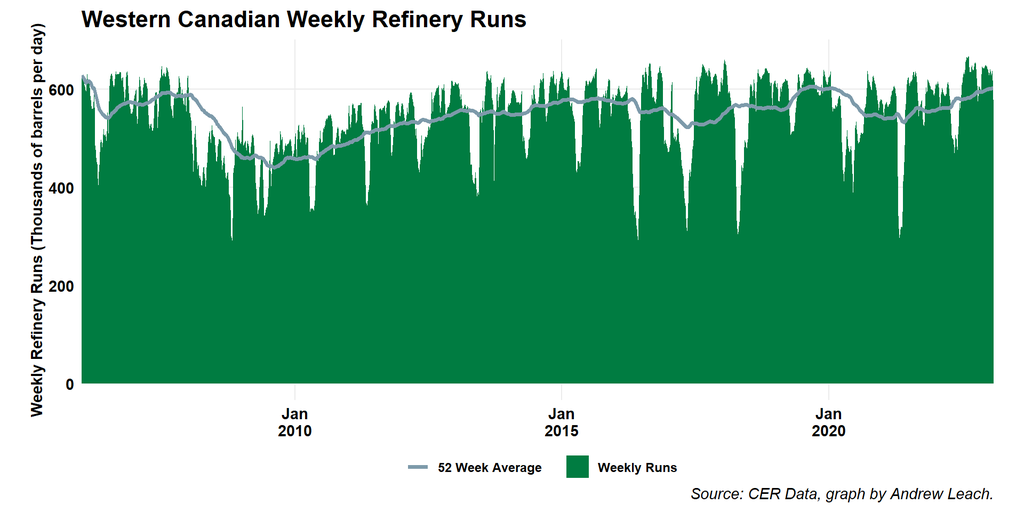

# Natural Gas

## Natural Gas Market Summary

### Feature Gas

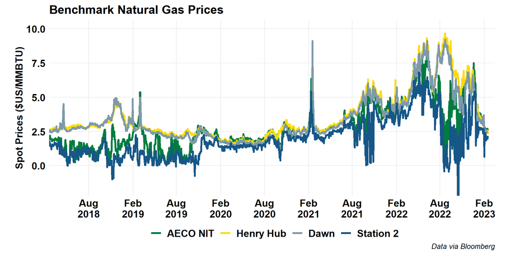

### Feature Gas (Short)

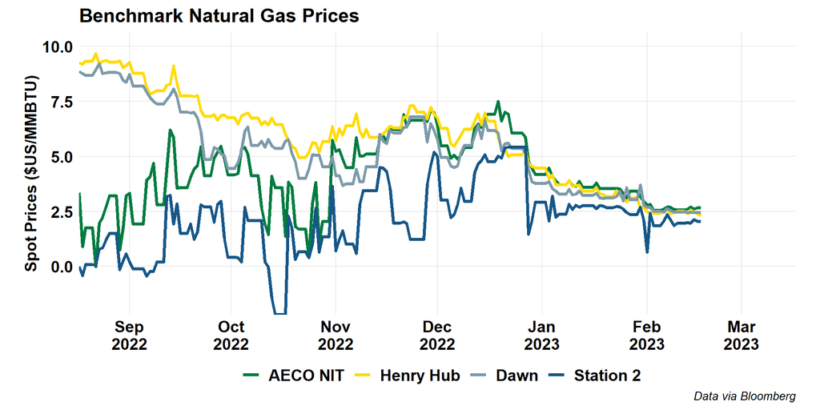

### Global Gas

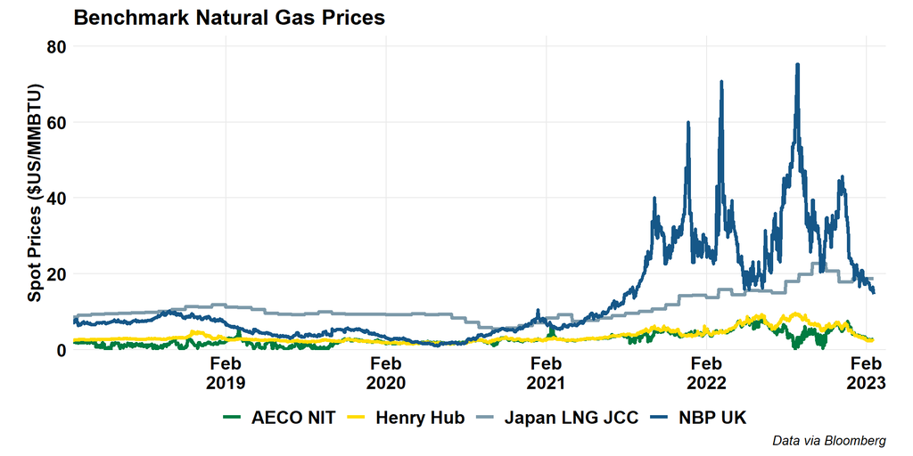

### North American Gas Hubs

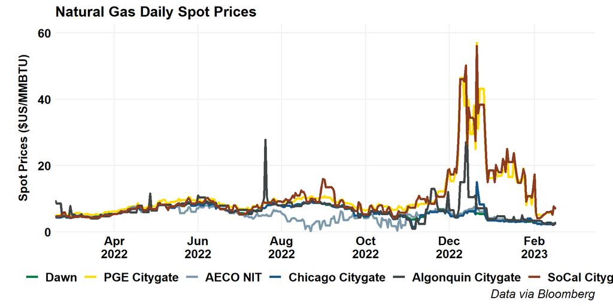